# Advanced Data Science in Python & R

Part 1: Deep Learning with Keras

Hosted by and maintained by the [Statistics Undergraduate Students Association (SUSA)](https://susa.berkeley.edu). Originally authored by Arun Ramamurthy & Patrick Chao.

# Introduction

Welcome to the first of SUSA’s crash courses on advanced data science in Python and R! In this tutorial, you will be learning about one of the most popular and versatile machine learning algorithms, **neural nets**, by using a package called **`Keras`** to implement a neural net model to recognize handwritten digits. We will be guiding you through an entire machine learning workflow, including exploratory data analysis (*EDA*), data cleaning, and the three components of modeling: **model training**, **model selection**, and **model evaluation**. We will even teach you a couple of neat tricks on how to visualize your models to understand their behavior and performance.

## About this Document

### Prerequisites

This workshop prerequires either experience in Python or R, to the degree covered by the previous [SUSA crash courses](http://github.com/SUSA-org/crash-course) - we recommend the completion of the introductory workbook series in both. This is partly to ensure you have the prior data wrangling and programming experience to understand the `Keras` code chunks at the end of this tutorial, but also to ensure you are caught up on the basics of machine learning practices covered incrementally in each workbook. At a minimum, you should understand the purposes of **training** and **validation**, the difference between **classification** and **regression**, and the **bias-variance tradeoff**. You must have RStudio, Python, and R installed to run this notebook. Visit [py0](https://raw.githubusercontent.com/SUSA-org/crash-course/master/Python/py0.html) for our crash course installation guide for Python. Visit r0 for general information on the philosophy and functionality of R and RStudio, as well as installation guides for both.

### adv-pyr1

This document contains textbook-style information on deep learning, as well as R programming as applied to deep learning models. It will cover the entirety of a `Keras` implementation of a neural net to classify handwritten digits. The Python implementation can be viewed in the adv-pyr1.ipynb notebook. The non-programmatic portions of these two documents are identical.

Throughout this tutorial, you will be working with the [**MNIST dataset**](https://en.wikipedia.org/wiki/MNIST_database), a dataset of seventy-thousand images of handwritten digits. You will be using this dataset to train a model to recognize the written digit given by a vector representing the image. More information on this dataset and its structure will be provided early in this tutorial.

Unlike some of the previous crash courses, this workbook will contain discussion and programming exercises throughout each section. These exercises are aimed at facilitating collaborative learning with your committee and target the core concepts and extensions of the techniques covered in this tutorial.

# Understanding the MNIST Dataset

Take a brief moment to read over the [MNIST Wikipedia article](https://en.wikipedia.org/wiki/MNIST_database).

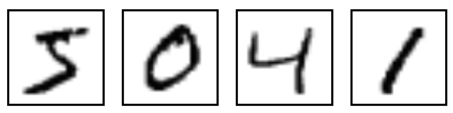

A small sample of the MNIST dataset.

The MNIST dataset consists of 70k images, 60k of which are considered the **training set**, with the remaining 10k for **test**. Each data entry $X_i$ in the MNIST dataset is a $28\times28$ pixel image of a single handwritten digit, and each is **labeled** with the associated digit between $0$ and $9$, denoted as $y_i$. Our goal is to design a model that learns a classification scheme from the 60k training images $\{X_i\}$ and their labels $\{y_i\}$, and then perform well in predicting which digit is represented in each test image.

#### Check for Understanding

> 1. Why is the MNIST dataset split into a training set and test set? Why do we want to avoid training our model on the test set?
> 2. If we instead had 10k training images and 60k test images, how might that affect the performance of our model?
> 3. How many different classes (e.g. different kinds of labels) are present in the MNIST dataset?
> 4. Can you think of a particular pair of numbers that might be particularly difficult to differentiate, or prone to misclassification with each other?

## Acquiring the MNIST Dataset

The MNIST data actually comes packaged with `keras`, a package which we will be using later to implement our deep learning model, by default. So, let’s install `keras` and take a look at the dataset.

## Installing `keras` in R

If you have `conda` installed on your machine (covered in [py0](https://raw.githubusercontent.com/SUSA-org/crash-course/master/Python/py0.html)), installing `keras` in R just takes a few short lines of code.

First, you have to install the `keras` package with the `install.packages` command. Unlike most R packages, which are self-contained, `keras` requires some extra libraries to run properly. So, after loading `keras` into your environment with the `library` command, there’s an additional step of installing all its dependancies using the `install_keras` command. In some cases, you may need to explicitly state the installation locations of `python` and `conda`. Fortunately, the `reticulate` package makes this easy, as you can check your installation locations with `py_discover_config`.

An example code chunk that installs `keras`, its dependancies, and then stores the MNIST dataset as `MNIST` is shown below:

```r
## install.packages(c("keras", "reticulate")) ## NOT RUN on knit
library(keras);library(reticulate)
py_discover_config() ## Use this to discover your installation locations for conda and python
```

```
## python:         /usr/bin/python
## libpython:      /usr/lib/python2.7/config-x86_64-linux-gnu/libpython2.7.so
## pythonhome:     /usr:/usr
## version:        2.7.12 (default, Dec  4 2017, 14:50:18)  [GCC 5.4.0 20160609]
## numpy:          /usr/lib/python2.7/dist-packages/numpy
## numpy_version:  1.11.0
##
## python versions found:
##  /usr/bin/python
##  /usr/bin/python3
##  /home/arun/.conda/bin/python
```

```r
keras::use_python("/home/arun/.conda/bin/python") ## As seen in the last line of the preceding output
## install_keras()
MNIST <- dataset_mnist()
```

## Installing `keras` in Python

Please refer to the Python version of the notebook.

## The Structure of the MNIST Dataset

We’ve successfully loaded `MNIST` into our environment, so let’s take a look at its structure.

```r
str(MNIST)
```

```
## List of 2
##  $ train:List of 2
##   ..$ x: int [1:60000, 1:28, 1:28] 0 0 0 0 0 0 0 0 0 0 ...
##   ..$ y: int [1:60000(1d)] 5 0 4 1 9 2 1 3 1 4 ...
##  $ test :List of 2
##   ..$ x: int [1:10000, 1:28, 1:28] 0 0 0 0 0 0 0 0 0 0 ...
##   ..$ y: int [1:10000(1d)] 7 2 1 0 4 1 4 9 5 9 ...
```

As we can see from the output of `str`, `MNIST` is a list of two datasets, `train` and `test`.

Each image $X_i$ is represented by a two-dimensional array (i.e. $28\times28$ matrix) of *grayscale intensities* ranging from $[0,255]$ to indicate the darkness of the ink at each pixel. $0$ represents a pixel that is completely white, and $255$ represents a pixel that is completely black.

#### Check for understanding

> 1. If the training set of 60k images is denoted by a set of $28\times28$ matricies $X$ = {$X_i$}, what are the possible values for $i$?
> 2. What does each $y_i$ represent, with respect to the corresponding $X_i$? What are the possible values for $y_i$?

Let’s split up our dataset into `training_set_*` and `test_set_*` variables for use in training and testing our model later.

```r
training_set_x <- MNIST$train$x
training_set_y <- MNIST$train$y

test_set_x <- MNIST$test$x
test_set_y <- MNIST$test$y
```